# Lab 12 - Stats 503

## Gaussian mixture models

We are going to perform color image segmentation with a gaussian mixture model. An example of an image can be downloaded from the data folder, but you are free to choose any image you like. Note that the method can be very slow for large image, so try to select one with small resolution.

The next function is useful to visualize an image in R.

```r
plot_img = function(V) {
  res = dim(V)
  V = aperm(V, c(2,1,3))
  plot(1,1,xlim=c(1,res[1]),ylim=c(1,res[2]),asp=1,type='n',xaxs='i',yaxs='i',xaxt='n',yaxt='n',xlab='',ylab='',bty='n')
  rasterImage(V,1,1,res[1],res[2])
}
```

Read and plot the image.

[figure not shown]

```r
library(ggplot2)
#source("http://bioconductor.org/biocLite.R")
#biocLite("EBImage")
library(EBImage)
library(jpeg)
img = readImage("starry.jpg")
img_rgb = img@.Data
plot_img(img_rgb)
```

Each pixel of an image is represented as a 3-dimensional vector, which indicates the intensity of red, green and blue colors.

```r
img_rgb = img@.Data
img_vec = array(0, dim = c(dim(img_rgb@.Data)[1]*dim(img_rgb@.Data)[2],3))
img_vec[,1] = img_rgb[,,1]
img_vec[,2] = img_rgb[,,2]
img_vec[,3] = img_rgb[,,3]
dim(img_vec)
```

```
## [1] 65536     3
```

```r
head(img_vec)
```

```
##           [,1]      [,2]      [,3]
## [1,] 0.6235294 0.6470588 0.4588235
## [2,] 0.7529412 0.7921569 0.6862745
## [3,] 0.5176471 0.5843137 0.6156863
## [4,] 0.5843137 0.6588235 0.8235294
## [5,] 0.4666667 0.5490196 0.7333333
## [6,] 0.5254902 0.5960784 0.6901961
```

The library *mclust* contains functions to fit gaussian mixture models. Note that we use a sample of 4000 points of the image for efficiency.

```r
library(mclust)
img_vec_sub = img_vec[sample(1:nrow(img_vec), 4000, replace = F),]
color.clust = Mclust(img_vec_sub, control = emControl(itmax = c(10,10))) #only 10 iterations to force it stop faster!
```

To interpret the selected model, the notation is the following E = equal, V = varying, I = identity 1st = volume, 2nd = shape, 3rd = orientation

```r
?mclustModelNames
```

```
## No documentation for 'mclustModelNames' in specified packages and libraries:
## you could try '??mclustModelNames'
```

```r
color.clust$modelName
```

```
## [1] "VVV"
```

We can plot the BIC as a function of the number of clusters.

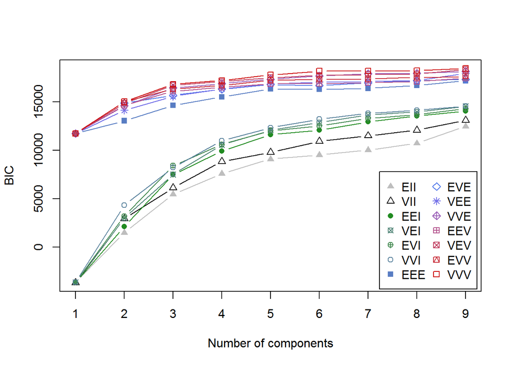

```r
plot(color.clust, what = "BIC")
```

To visualize the means of each cluster and the proportions, use a pie plot.

```r
# Cluster proportions
color.clust$parameters$pro
```

```
## [1] 0.11141791 0.14672832 0.20402402 0.13426682 0.09623452 0.12027257
## [7] 0.10674357 0.05768727 0.02262501
```

```r
# Cluster means
color.clust$parameters$mean
```

```
##           [,1]      [,2]      [,3]      [,4]       [,5]      [,6]
## [1,] 0.3317774 0.5508408 0.2215109 0.1460222 0.11980648 0.4530373
## [2,] 0.4743166 0.6275581 0.2893222 0.1530804 0.08942415 0.6327248
## [3,] 0.7915019 0.6619513 0.5787100 0.2224928 0.05253087 0.9063691
##           [,7]      [,8]       [,9]
## [1,] 0.7330963 0.9393939 0.94272509
## [2,] 0.8236358 0.9401682 0.85272388
## [3,] 0.8463131 0.5522932 0.07546312
```

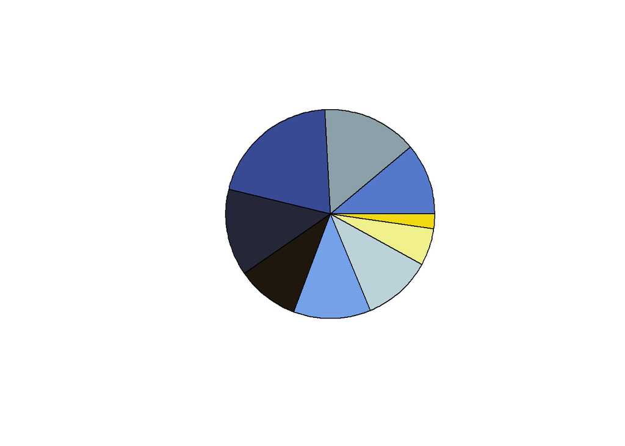

```r
img_colors <- rgb(color.clust$parameters$mean[1,],color.clust$parameters$mean[2,],color.clust$parameters$mean[3,])

pie(color.clust$parameters$pro, labels = NA, col = img_colors)
```

Finally, we can assign each point to its cluster, and visualize the results (for reference, the original image is included).

[figure not shown]

[figure not shown]

```r
fitted_colores <- predict.Mclust(color.clust, img_vec)
centers = color.clust$parameters$mean
img_filt = img_rgb
img_filt[,,1] = centers[1,fitted_colores$classification]
img_filt[,,2] = centers[2,fitted_colores$classification]
img_filt[,,3] = centers[3,fitted_colores$classification]
plot_img(img_filt)
```

## Mixture models and the EM algorithm

Now, we are going to perform clustering in graphs, a problem usually called *community detection*. The idea is to find groups of *friends* in a network that are more densely connected between people of the same community than with people in other communities. We will use the Zachary’s karate club network, a popular example to test community detection algorithms (there is even a prize for using it http://networkkarate.tumblr.com/).

```r
library(igraph)
#install.packages("igraphdata")
library(igraphdata)
data("karate")
library(Matrix)
```

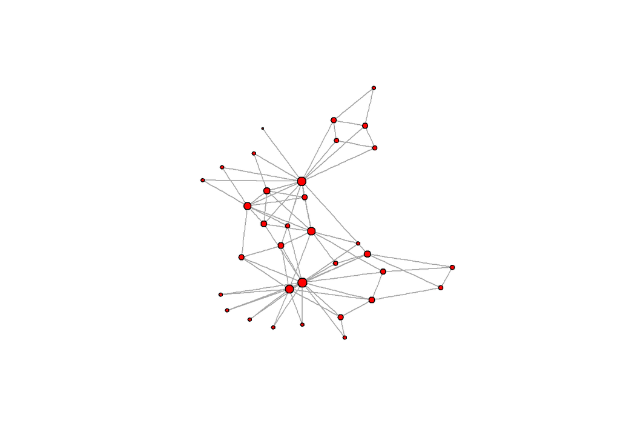

```r
A = Matrix(get.adjacency(karate))
layout <- layout.fruchterman.reingold(karate)
degree <- apply(A,1,sum)
plot.igraph(karate,
            layout = layout,
            vertex.color = "red",
            vertex.label=NA,
            vertex.size=2*(log(degree)+1))
```

The stochastic blockmodel (SBM) for two communities is defined as follows

- There are $n$ nodes in the network. Each node has an unknown community label $Z_i\in\{1,2\}$, and for each $i=1,\ldots,n$,
  $$P(Z_i=1)=\pi_1,$$
  $$P(Z_i=2)=\pi_2=1-\pi_1.$$
- Edges are represented with an adjacency matrix $A\in\{0,1\}^{n\times n}$. For a given pair of nodes $i$ and $j$, the probability of an edge only depends on the community labels $Z_i$ and $Z_j$, so
  $$P(A_{ij} = 1| Z_i=z_i, Z_j=z_j) = p_{z_iz_j}.$$
  The matrix $p\in[0,1]^{2\times 2}$ encodes the probabilities of an edge betwen and within communities.

### EM algorithm

We can fit the SBM using the EM algorithm. Let $\tau_{ik}=P(Z_{i}=k|A)$. Using initial values $\tau^{(0)}$, $\pi_1^{(0)},\pi_2^{(0)}$ and $p^{(0)}$, the algorithm iterate until convergence

- E-step: Given current estimates of $\pi_1$, $\pi_2$ and $p$, update $\tau_{ik} = P(Z_i=k|A)$
- M-step: Update $\pi_1,\pi_2$ and $p$ by maximizing $E(L_c(\pi_1,p|D_C)|D)$, where $L_c$ is the loglihelihood of the complete data and $D_C$ is the complete data.

The EM algorithm for the SBM can be written as

- E-step. For $i=1,\ldots, n$, update $\tau_{ik}$ as
  $$\tau_{ik} \leftarrow \frac{P(A|Z_i=k)\pi_k}{P(A)},$$
  for $k=1,2.$
- M-step:
  $$p_{km} \leftarrow \frac{\sum_{i\neq j} A_{ij}\tau_{ik}\tau_{jk}}{\sum_{i\neq j}\tau_{ik}\tau_{jm}},$$
  $$\pi_{k} \leftarrow \frac{1}{n}\sum_{i=1}^n \tau_{ik}.$$

Note that in order to calculate $\tau_{ik}$ on the E-step, we need to condition on all $Z_j$, and that results in a sum that is computationally very difficult to calculate! A solution is to use *variational inference*, and it results in the following step.

$$\tau_{ik} \propto \pi_k \prod_{j\neq i}\prod_{m=1}^2 \left(p_{km}^{A_{ij}}(1-p_{km})^{1-A_{ij}}\right)^{\tau_{jm}}.$$
Computational note: for large networks, the product above can be numerically very small, so it is usually a good idea to use a logarithmic transformation.

The previous method requires a good starting value. We can use the *spectral clustering* algorithm, which consists in calculating the 2 leading eigenvectors of the normalized laplacian of the network, and then performing k-means to partition the nodes into two differenc clusters (see code below).

```r
n = ncol(A)
#Degree
D = apply(A,1,sum)
# Calculate normalized laplacian
L = diag(1/sqrt(D)) %*% A %*% diag(1/sqrt(D))
K = 2
eig = eigen(L)
# K leading eigenvectors
V = eig$vectors[,order(abs(eig$values),decreasing = T)[1:K]]
spectral_clust = kmeans(V,centers = K)
```

Now, we can use the previous solution to initialize the variational EM algorithm for the SBM.

```r
# Normalize exp(x), to avoid numerical issues
normalize_log_probabilities <- function(p_arr) {
  maxP = max(p_arr)
  as.double(exp(p_arr-maxP)/sum(exp(p_arr-maxP)))
}

# Initialize parameters using spectral clustering solution
tau = matrix(0, nrow = n, ncol = 2)
tau[spectral_clust$cluster==1,1] = 1
tau[spectral_clust$cluster==2,2] = 1
pi = apply(tau,2,mean)
p_matrix = crossprod(tau, crossprod(A, tau)) /(tcrossprod(apply(tau,2,sum)) - crossprod(tau))
converge = FALSE
iter = 0
# Iterate until convergence
while(!converge & iter < 100) {
  # E- step--------------------------
  tau_old = tau
  for(i in 1:n) {
    tau[i, ] = normalize_log_probabilities(log(pi) + A[i,-i]%*%tau[-i,] %*% log(p_matrix) + (1-A[i,-i])%*%tau[-i,] %*% log(1-p_matrix))
  }
  # M-step---------------------------
  pi = apply(tau,2,mean)
  p_matrix =  crossprod(tau, crossprod(A, tau)) /(tcrossprod(apply(tau,2,sum)) - crossprod(tau))
  #Check convergence
  converge = norm(tau-tau_old)<1e-5
  iter = iter + 1
}

cluster = apply(tau,1, which.max)
```

We can visualize the solution of the clustering procedure by coloring the nodes according to the estimated communities.

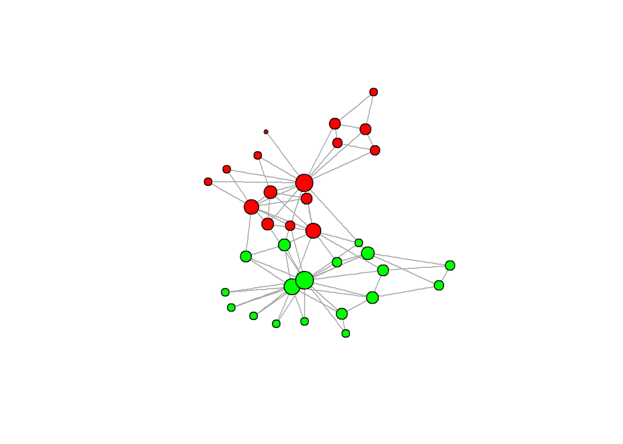

```r
cols = c("green", "red")[cluster]

plot.igraph(karate,
            layout = layout,
            vertex.color = cols,
            vertex.label=NA,
            vertex.size=4*(log(degree)+1))
```

For comparison, here are the colors of the actual communities that formed in the karate club.

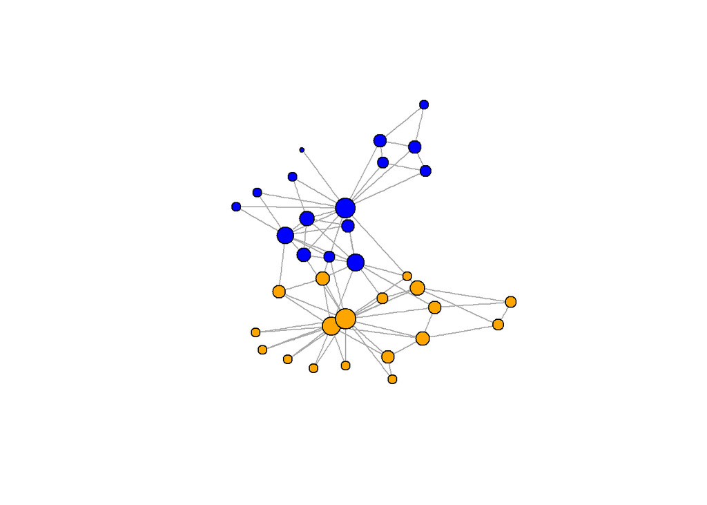

```r
cols = c("blue", "orange")[get.vertex.attribute(karate)$Faction]
plot.igraph(karate,
            layout = layout,
            vertex.color = cols,
            vertex.label=NA,
            vertex.size=4*(log(degree)+1))
```

## Exercises

The SBM can be extended to handle $K$ communities, so now $Z_i\in{1,\ldots,K}$, $P(Z_i=k)=\pi_k$, where $\pi_1,\ldots,\pi_K$ are numbers such that $\pi_1+\ldots+\pi_K=1$, and the matrix $p$ has dimension $K\times K$,

1. Check that the steps of the EM algorithm for the SBM with $K$ networks are the same as the ones defined before.
2. Modify the code for two communities to handle $K$ communities (you only need to make sure that the dimensions are correct).
3. Download some network data and use the method to find communities.
- You can use the Facebook network of Simmons College students, which represents the Facebook friendship relations between students on this college. Download the file Simmons81.mat from the data folder and use the following code to load it into R. (Note: the code selects nodes of students from the class 2006 to 2009 who have at least one friend)

```r
library(R.matlab)
fileNet = readMat("Simmons81.mat")
A = fileNet$A
year = fileNet$local.info[,6]
# Select nodes from years 2006-2009
sel_nodes = which(fileNet$local.info[,1]==1 & fileNet$local.info[,6]>=2006 &
                    fileNet$local.info[,6]<=2009)
year = year[sel_nodes]
A = A[sel_nodes,sel_nodes]
# Select nodes with at least one friend
sel_nodes = which(apply(A,1,sum)>0)
A = A[sel_nodes,sel_nodes]
year = year[sel_nodes]
Simmons_network = graph.adjacency(A, mode = "undirected", diag = F)
```

- Fit the SBM using the EM algorithm. Play with different values of $K$ and visualize the results. (Note: you will probably have to limit the number of iterations a lot).
- Using $K=4$, compare your results with the labels given by the year (we can expect that most friendships will occur between people that started the college during the same year, so this can be a good approximation of communities).
- Compare the results with the solution of spectral clustering.